# Plotting with ggplot

Part of the Introduction to R and key packages traning session

Bo Gao

04/03/2021

# 1 Lecture

## 1.1 Basics

Each graph produced by `ggplot` is a top-down view on a stack of plots. At the bottom of this stack is the `ggplot` function which holds the **data** component. This data set is then mapped by `geom_*` functions (i.e. the **geom** component) onto a **coordinate system** to produce a plot. Each geom function has its own geometry definition of how to present the data. For instance, `geom_line()` draws lines through data points, `geom_point()` draws data points as individuals, and `geom_histogram` puts values of the plotted variable into bins before drawing vertical bars showing the size of each bin.

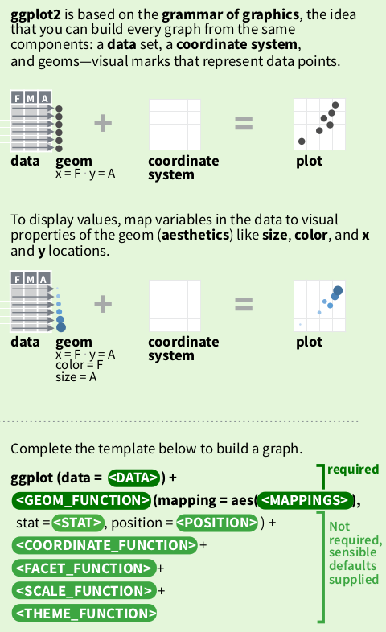

source: https://github.com/rstudio/cheatsheets/raw/master/data-visualization-2.1.pdf

As well as `ggplot` and `geom_*` functions, we have other functions such as `theme_*` functions and `scale_*` functions to tweak other elements of the graph. This group of functions are not strictly required from the user. `ggplot` provides default values in absence of user defined functions. To make publication quality graphs, it is essential to understand how these functions work.

## 1.2 Time series plot

### 1.2.1 Prepare data

We start by loading the `cases.Rda` file used by the CoMo app

```r
#try(lapply(paste('package:',names(sessionInfo()$otherPkgs),sep=""),detach,character.only=TRUE,unload=TRUE), silent = TRUE) # clear additional package space if any is loaded
rm(list = ls()) # delete all objects in current environment

library(rmarkdown) # paged_table
library(ggplot2)

load(url("https://github.com/ocelhay/como/raw/master/inst/comoapp/www/data/cases.Rda"))
ls()
```

```
[1] "cases" "tests"
```

Two variables loaded. What’s in `cases`

```r
paged_table(cases)
```

| country | date | cumulative_cases | cumulative_death | seroprevalence | cases | deaths |
| --- | --- | --- | --- | --- | --- | --- |
| Bahrain | 2019-12-31 | 0 | 0 | NA | NA | NA |
| Croatia | 2019-12-31 | 0 | 0 | NA | NA | NA |
| Germany | 2019-12-31 | 0 | 0 | NA | NA | NA |
| Iran | 2019-12-31 | 0 | 0 | NA | NA | NA |
| Iraq | 2019-12-31 | 0 | 0 | NA | NA | NA |
| Italy | 2019-12-31 | 0 | 0 | NA | NA | NA |
| Lithuania | 2019-12-31 | 0 | 0 | NA | NA | NA |
| Monaco | 2019-12-31 | 0 | 0 | NA | NA | NA |
| Mexico | 2019-12-31 | 0 | 0 | NA | NA | NA |
| Nigeria | 2019-12-31 | 0 | 0 | NA | NA | NA |

[output cut: 990 more lines]

Get UK specific time series

```r
uk_cases <- cases[cases[["country"]] == "United Kingdom",] # filter rows
uk_cases <- uk_cases[c("country", "date", "cases")]        # pick columns
uk_cases <- uk_cases[rowSums(is.na(uk_cases)) == 0,]       # remove NAs
paged_table(uk_cases)
```

| country | date | cases |
| --- | --- | --- |
| United Kingdom | 2020-01-01 | 0 |
| United Kingdom | 2020-01-02 | 0 |
| United Kingdom | 2020-01-03 | 0 |
| United Kingdom | 2020-01-04 | 0 |
| United Kingdom | 2020-01-05 | 0 |
| United Kingdom | 2020-01-06 | 0 |
| United Kingdom | 2020-01-07 | 0 |
| United Kingdom | 2020-01-08 | 0 |
| United Kingdom | 2020-01-09 | 0 |
| United Kingdom | 2020-01-10 | 0 |

[output cut: 339 more lines]

### 1.2.2 First graph

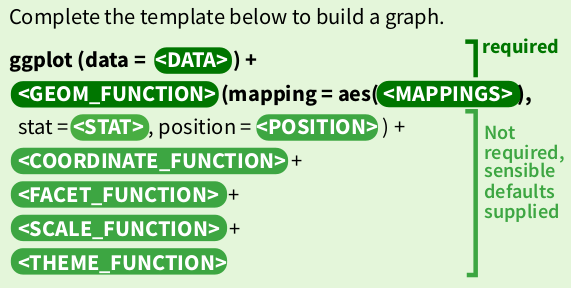

source: https://github.com/rstudio/cheatsheets/raw/master/data-visualization-2.1.pdf

`ggplot2`’s *grammar of graphics* states that graphs are built from 3 components:

- a data set
- a coordinate system
- geoms (specifications of aesthetic elements e.g. x and y locations, shape, size, and colour of data points)

Where a sensible default coordinate system is useful for most graphs, the `<data>` and `<geoms>` components need to be provided by the user.

Here we tell `ggplot` that we want to draw a plot based on a data frame named `uk_cases`, and we pick the `geom_point` function to draw the data as points on the graph. We want to map the `date` column to the x axis, and the `cases` column to the y axis.

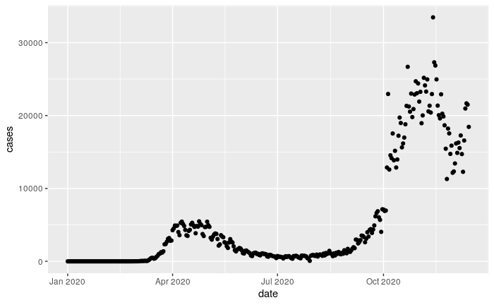

```r
ggplot(data = uk_cases) +                        # data
  geom_point(mapping = aes(x = date, y = cases)) # geom_func(mapping)
```

This is good, but often time series are drawn as lines. So let’s replace `geom_point` with `geom_line`

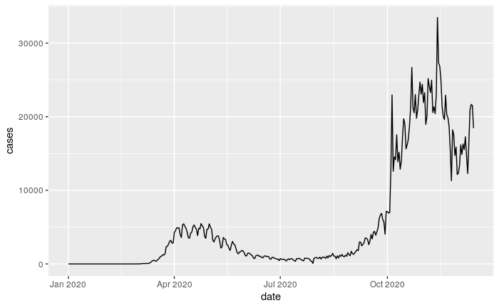

```r
ggplot(data = uk_cases) +                       # data
  geom_line(mapping = aes(x = date, y = cases)) # geom_func(mapping)
```

This looks better already. But what if I want both points and lines? Let’s stack the two layers together. Also, we also add an additional `geom_smooth` layer to give us some visual on the overall trend.

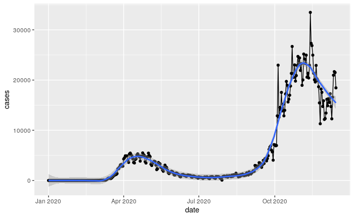

```r
ggplot(data = uk_cases) +
  geom_point(mapping = aes(x = date, y = cases)) +
  geom_line(mapping = aes(x = date, y = cases)) +
  geom_smooth(mapping = aes(x = date, y = cases), method = "loess", span = .2)
```

The graph is overly busy for no good reason now, but we demonstrated how different layers can be created by different `geom` functions and stacked together. More on `geom_smooth` please read: https://ggplot2.tidyverse.org/reference/geom_smooth.html, and on `loess` : https://en.wikipedia.org/wiki/Local_regression

### 1.2.3 Inheritance

So far the `data + geom_func(aes)` grammar is readable from the code, but we also see some repetition of code segment such as `mapping = aes(x = date, y = cases)` which appears 3 times in our code. Knowing the inheritance between `ggplot` and `geom_*` functions (`inherit.aes` property) is true by default, we put the mapping definition to the base layer (the `ggplot` function) of the code.

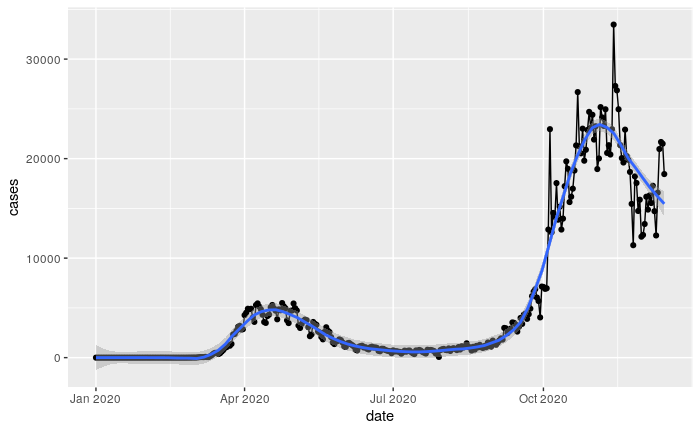

```r
ggplot(uk_cases, aes(x = date, y = cases)) +
  geom_point() + geom_line() + geom_smooth(span = .2)
```

Exactly the same plot. Note that we lost the `data` and `mapping` keywords too, and the `aes` definition only appear once in the code. We now have shorter and easier code to maintain, but the *grammar* in **grammar of graphics** has become less obvious. This is also why every online tutorial is slightly different to each other despite performing the same actions.

### 1.2.4 Adding more time series

Get data for United States in `us_cases`.

```r
us_cases <- cases[cases[["country"]] == "United States",] # filter rows
us_cases <- us_cases[c("country", "date", "cases")]       # pick columns
us_cases <- us_cases[rowSums(is.na(us_cases)) == 0,]      # remove NAs
paged_table(us_cases)
```

| country | date | cases |
| --- | --- | --- |
| United States | 2020-01-01 | 0 |
| United States | 2020-01-02 | 0 |
| United States | 2020-01-03 | 0 |
| United States | 2020-01-04 | 0 |
| United States | 2020-01-05 | 0 |
| United States | 2020-01-06 | 0 |
| United States | 2020-01-07 | 0 |
| United States | 2020-01-08 | 0 |
| United States | 2020-01-09 | 0 |
| United States | 2020-01-10 | 0 |

[output cut: 339 more lines]

We reset the UK time series to just one plot using the points and add the US time series as a line. The UK case numbers look a lot less scary now.

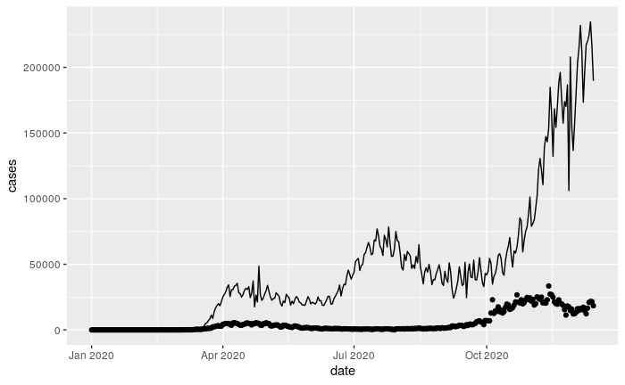

```r
ggplot(uk_cases, aes(x = date, y = cases)) +
  geom_point() + geom_line(data = us_cases)
```

The `data = us_cases` statement in `geom_line()` now overwrites the `data = uk_cases` statement inherited from `ggplot`. [^1]

Let’s add the world total number of daily cases in to our graph too. We draw all three time series with lines.

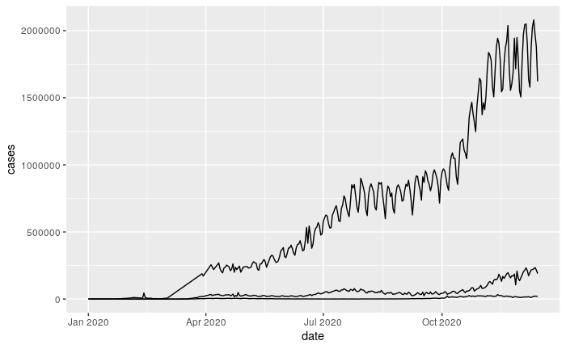

```r
world_sum <- aggregate(cases[, "cases"], list(date = cases[["date"]]), sum) # Forgot to filter the rows for the continents here
world_sum <- world_sum[rowSums(is.na(world_sum)) == 0,]

ggplot(mapping = aes(x = date, y = cases)) +
  geom_line(data = world_sum) + geom_line(data = uk_cases) + geom_line(data = us_cases)
```

Note that each of the three lines are from a different data frame. [^2]

### 1.2.5 Colours, labels, scales, and coordinates

Now let’s better the graph so that

- The three time series are distinguishable
- Both axes are labeled clearly
- Ticks on the axes are more informative
- Y is in log-scale
- Remove the grey background
- Truncate the lines so that the plot covers exactly one year in time

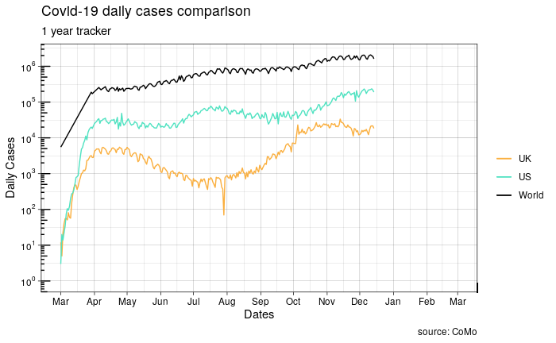

```r
options(scipen = 999)  # turn off scientific notation like 1e+06

g <- ggplot(mapping = aes(x = date, y = cases)) +
  geom_line(data = world_sum, aes(color = "World"),) +
  geom_line(data = uk_cases,  aes(color = "UK"),) +
  geom_line(data = us_cases,  aes(color = "US"),) +
  labs(x = "Dates", y = "Daily Cases", title = "Covid-19 daily cases comparison", subtitle = "1 year tracker", caption = "source: CoMo") +
  # scale_y_log10(
  #   breaks = scales::trans_breaks("log10", function(x) 10^x),
  #   labels = scales::trans_format("log10", scales::math_format(10^.x))
  # ) +
  scale_y_continuous(
    trans = "log10",
    breaks = scales::trans_breaks("log10", function(x) 10^x),
    #minor_breaks = scales::trans_breaks("log10", function(x) 10^x+x),
    labels = scales::trans_format("log10", scales::math_format(10^.x))
  ) +
  annotation_logticks() +
  theme_linedraw() +
  scale_color_manual(name="", values = c("World" = "black", "US"="#50e2c1", "UK"="#faaf3f"))

g1 <- g + scale_x_date(date_labels = "%b", date_breaks = "1 month", limits = as.Date(c("2020-03-01", "2021-03-01")))
plot(g1)
```

- [Scales](https://ggplot2.tidyverse.org/reference/scale_continuous.html)
- [Axis labels](https://ggplot2.tidyverse.org/reference/labs.html)
- Log-scale [annotation_logticks](https://ggplot2.tidyverse.org/reference/annotation_logticks.html)

### 1.2.6 Coordinate system

We can set x range by adjusting the `<coordinate system>` (last element of the grammar) instead.

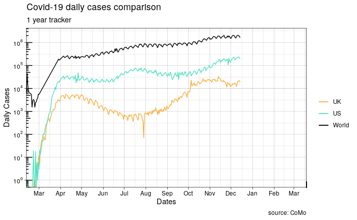

```r
g2 <- g + coord_cartesian(xlim = as.Date(c("2020-03-01", "2021-03-01"))) + scale_x_date(date_labels = "%b", date_breaks = "1 month")

plot(g2)
```

Note how `g1` and `g2` differ at truncating the lines at the beginning: - `g1` - setting `limits` in the `scale` function truncates the data before they are plotted - `g2` - changing the coordinate system only modifies the viewing-window of the graph

This is mostly useful when you want to zoom in to an area of the plot.

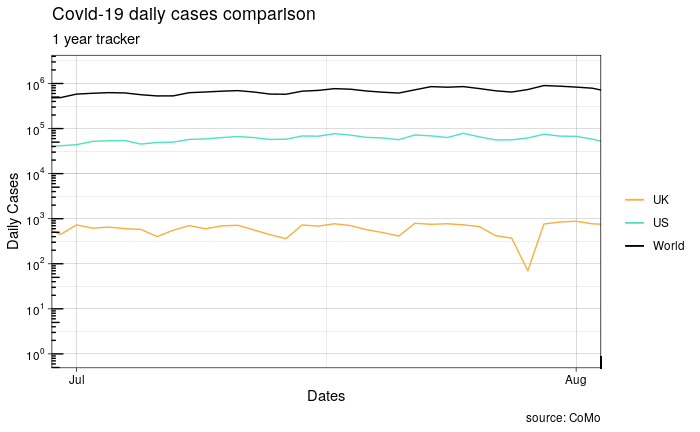

```r
g2 <- g + coord_cartesian(xlim = as.Date(c("2020-07-01", "2020-08-01"))) + scale_x_date(date_labels = "%b", date_breaks = "1 month")

plot(g2)
```

### 1.2.7 Annotations

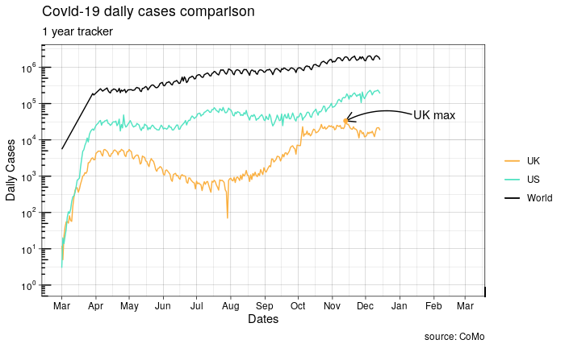

```r
uk_peak <- uk_cases[which.max(uk_cases[["cases"]]),]
g11 <- g1 +
  geom_curve(aes(
      xend = uk_peak[["date"]],
      yend = uk_peak[["cases"]],
      x = uk_peak[["date"]]+60,
      y = uk_peak[["cases"]]*1.5
    ),
    curvature = 0.2,
    arrow = arrow(length = unit(10, "points"))
  ) +
  geom_point(data = uk_peak, color = "#ffaf3f") +
  annotate(
    geom = "text",
    label = "UK max",
    x = uk_peak[["date"]]+80,
    y = uk_peak[["cases"]]*1.5
  )
plot(g11)
```

More on [annotate](https://ggplot2.tidyverse.org/reference/annotate.html)

# 2 Hands on

## 2.1 Long and wide data format

In the previous section, we used three separate data frames side by side which resembles a **Wide** data format. For data in this format, each series is stored in its own column. No filtering is needed once the column has been specified. The `<data>` component needs redefinition in each `<geom>` layer because a different column is used.

The same set of data can be rearranged in a **Long** format. In such format, all series keep their data in the same column. To distinguish ownership of each row’s data, an extra column is created.

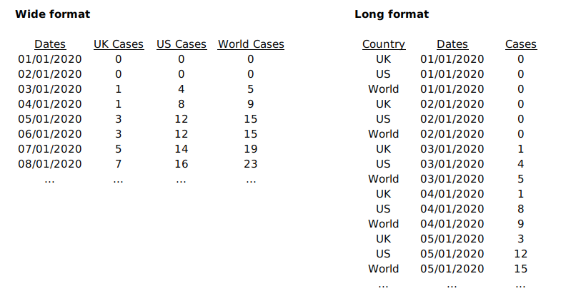

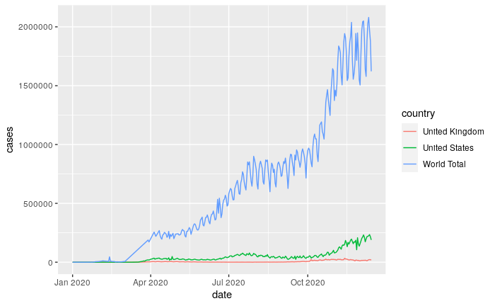

```r
world_sum["country"] <- "World Total"
long_data <- rbind(uk_cases, us_cases, world_sum)
ggplot(data = long_data, mapping = aes(x = date, y = cases)) +
  geom_line(aes(colour = country))
```

Note how R automatically added a legend to the plot. This comes when an aesthetic setting is dependent on a column,`colour = country` in this case.

## 2.2 More plot types

### 2.2.1 Scatter

```r
per_country_sum <- aggregate(x = list(cases[, "cases"], cases[,"deaths"]), by = list(country = cases[["country"]]), FUN = sum, na.rm = TRUE)

library("countrycode")
per_country_sum[["continent"]] <- countrycode(
                                      sourcevar = per_country_sum[,"country"],
                                      origin = "country.name",
                                      destination = "continent"
                                    )
```

```
Some values were not matched unambiguously: Africa, America, Asia, Europe, Kosovo, Oceania, Other continent, World
```

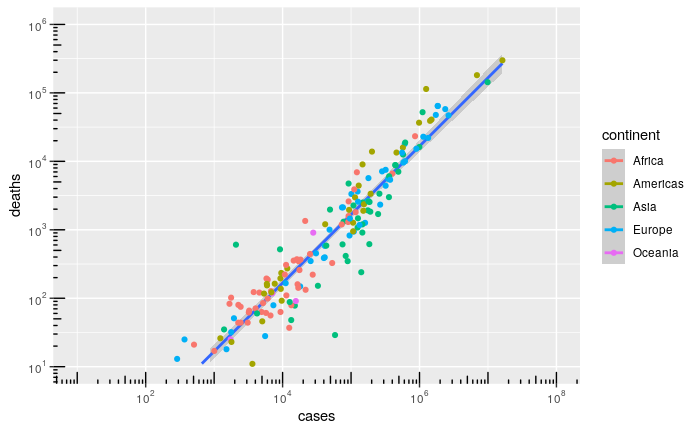

```r
per_country_sum <- per_country_sum[rowSums(is.na(per_country_sum)) == 0,]
per_country_sum <- per_country_sum[per_country_sum["deaths"] > 10,]

#paged_table(per_country_sum)

g3 <- ggplot(data = per_country_sum, aes(x = cases, y = deaths, colour = continent)) +
  geom_smooth(data = per_country_sum, mapping = aes(colour = NULL), method = "lm", span = .2) +
  geom_point() +
  scale_y_log10(
    breaks = scales::trans_breaks("log10", function(x) 10^x),
    labels = scales::trans_format("log10", scales::math_format(10^.x)),
    limits = c(10,10^6)
  ) +
  scale_x_log10(
    breaks = scales::trans_breaks("log10", function(x) 10^x),
    labels = scales::trans_format("log10", scales::math_format(10^.x)),
    limits = c(10,10^8)
  ) +
  annotation_logticks() +
  coord_fixed()
plot(g3)
```

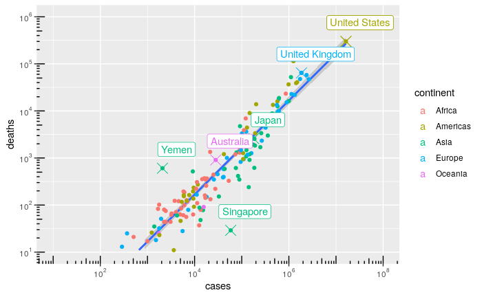

```r
min_death_rate <- per_country_sum[
                    which.min(
                      per_country_sum[["deaths"]]/per_country_sum[["cases"]]
                    ),
                  ]
max_death_rate <- per_country_sum[
                    which.max(
                      per_country_sum[["deaths"]]/per_country_sum[["cases"]]
                    ),
                  ]
max_death_count <- per_country_sum[
                    which.max(
                      per_country_sum[["deaths"]]
                    ),
                  ]
max_cases_count <- per_country_sum[
                    which.max(
                      per_country_sum[["cases"]]
                    ),
                  ]

interested_countries <- per_country_sum[is.element(
                            per_country_sum[["country"]],
                            c("United Kingdom", "Australia", "Japan")
                        ),]

highlighted_rows <- rbind(
                      min_death_rate,
                      max_death_rate,
                      max_death_count,
                      max_cases_count,
                      interested_countries
                    )

g31 <- g3 +
  geom_point(
    data = highlighted_rows,
    shape = 4,
    size = 5
  ) +
  geom_label(
    data = highlighted_rows,
    mapping = aes(label = country),
    nudge_x = 0.3,
    nudge_y = 0.4
  )

plot(g31)
```

### 2.2.2 Density

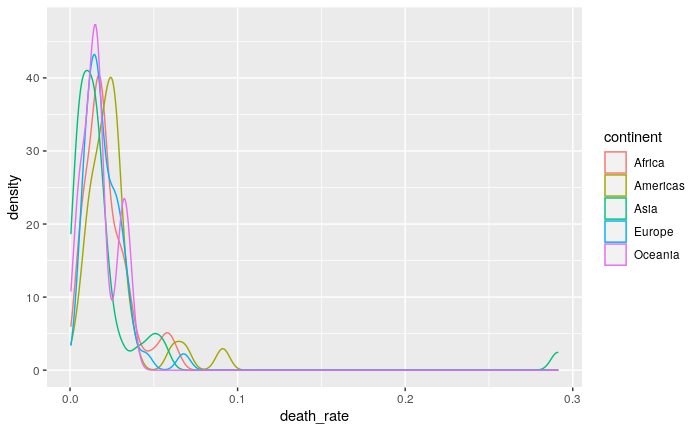

```r
per_country_sum[["death_rate"]] <- per_country_sum[["deaths"]]/per_country_sum[["cases"]]

g4 <- ggplot(per_country_sum, aes(x = death_rate))
g4 +
  geom_density(aes(color = continent), alpha = 0.4) #+
```

```r
  #scale_x_continuous(limits = c(0,0.1))
```

### 2.2.3 Boxplot

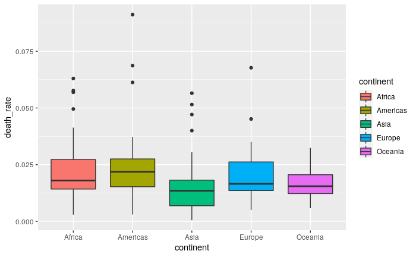

```r
#per_country_sum[["death_rate"]] <- per_country_sum[["deaths"]]/per_country_sum[["cases"]]
per_country_sum_no_yemen <- per_country_sum[per_country_sum[["country"]] != "Yemen",]

g5 <- ggplot(
  per_country_sum_no_yemen,
  aes(
    x = continent,
    y = death_rate,
    fill = continent,
  ),
  alpha = 0.5
)
g_vio <- g5 + geom_violin()
g_box <- g5 + geom_boxplot()
plot(g_box)
```

## 2.3 Other related packages

### 2.3.1 ggsci

Scientific Journal and Sci-Fi Themed Color Palettes for ggplot2

### 2.3.2 gridExtra

left to right by default

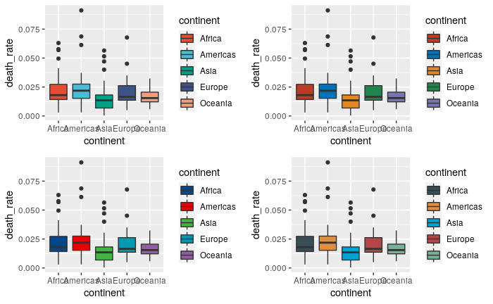

```r
library("ggsci")
library("gridExtra")
g_box_npg <- g_box+scale_fill_npg()
g_box_nejm <- g_box+scale_fill_nejm()
g_box_lancet <- g_box+scale_fill_lancet()
g_box_jama <- g_box+scale_fill_jama()
grid.arrange(g_box_npg, g_box_nejm, g_box_lancet, g_box_jama, ncol = 2)
```

### 2.3.3 ggExtra

```
Removed 6 rows containing missing values (geom_smooth).
```

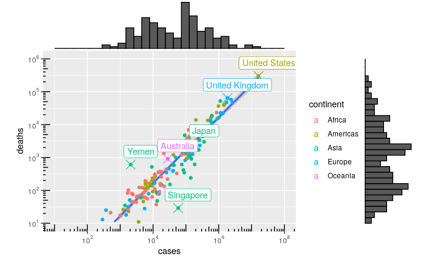

```r
library("ggExtra")
ggMarginal(g31, type = "histogram")
```

## 2.4 The `+` operator

Each layer on the ggplot graph stack is defined by a function, and these functions are all concatenated with the `+` operator. We know how `+` is defined for literals, such as in `1 + 2` or `"abc" + "def"`. But what does it do in between functions that don’t return a value?

Whereas commonly used math functions such as `max`, `abs`, and `sqrt` return the user with a numerical value, these functions such as the geom functions perform a set of procedures that either produce or modify a plot or several plots in the graph stack. The `+` operator here not only *sticks* these plots and performs the procedures one by one to produce the final graph. Because these functions are of different nature, the `+` operator in this context also acts as a [*dispatcher*](https://en.wikipedia.org/wiki/Multiple_dispatch). For those interested in knowing more about this subject and what’s going on behind the scenes:

```r
> ggplot2:::`+.gg`
function (e1, e2) {
  e2name <- deparse(substitute(e2))
  if (is.theme(e1))
    add_theme(e1, e2, e2name)
  else if (is.ggplot(e1))
    add_ggplot(e1, e2, e2name)
}
```

ref: https://stackoverflow.com/questions/40450904/how-is-ggplot2-plus-operator-defined

# 3 References

- R Basics http://r-statistics.co/R-Tutorial.html
- Cheat Sheet https://github.com/rstudio/cheatsheets/raw/master/data-visualization-2.1.pdf
- 50 Examples http://r-statistics.co/Top50-Ggplot2-Visualizations-MasterList-R-Code.html
- Documentation https://ggplot2.tidyverse.org/index.html
- `vignette("ggplot2-specs", package = "ggplot2")`
- ggplot2: Elegant Graphics for Data Analysis https://ggplot2-book.org/introduction.html
- How is ggplot2 plus operator defined? https://stackoverflow.com/questions/40450904/how-is-ggplot2-plus-operator-defined
- Be Awesome in ggplot2: A Practical Guide to be Highly Effective - R software and data visualization link
- grid.arrange https://cran.r-project.org/web/packages/egg/vignettes/Ecosystem.html
[^1]: Here the `aes` did not need to be re-stated in `geom_line` despite having a different `data` to plot. Why?
[^2]: If we remove `mapping =` from `ggplot` so that it is written like `ggplot(aes(x = date, y = cases)) + ....` would it still work?